# Portfolio Project

Author

Quinn Lynas

### Data Cleaning

The data set required some fixing with the zip codes. Some of the easterly states who’s zip starts with zero mistakenly read in as only 4 digit zips. I had to put a zero at the front of every zip with that problem. On top of that, one of the cities had missing data for zip code, so I manually coded in the city’s zip. I used a package called “zipcode” which contains a data set with longitude and latitude coordinates for each zip code in the United States. I joined this data set with the original so that each observation had coordinates. I also used the “lubridate” package to format the shipping dates better.

### Visualizations 1 and 2

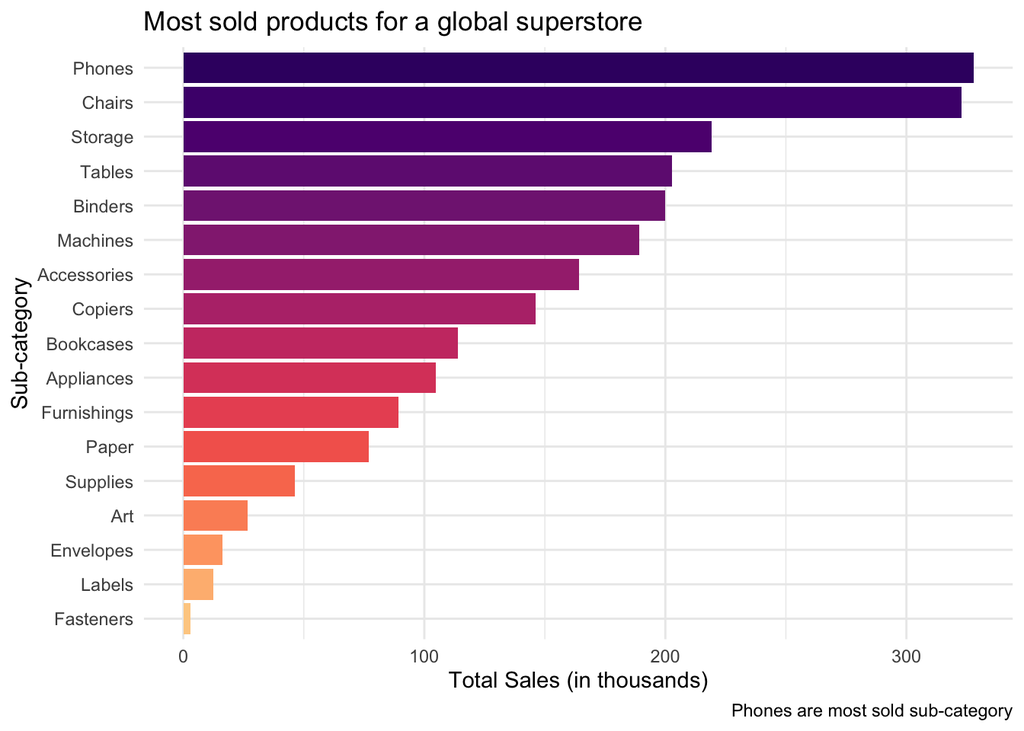

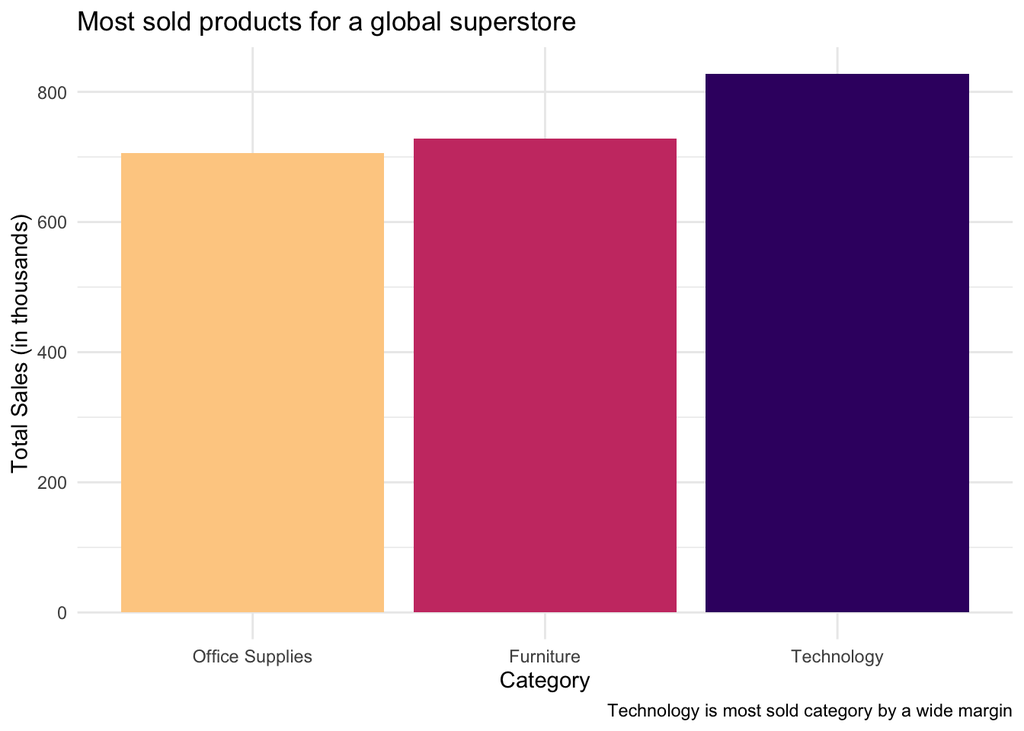

### Visualizations 3, 4, 5, and 6

*Research Question 2:* What state has the most products purchased?

The next four visualizations aim to answer the above research question. The first visualization answers the research question, as you can clearly see California has the most total sales. This visualization and the next only show the states which are top 10 for total sales. The second visualization shows a map of the U.S. and the sales between each of the states. You can see there is a very high density for sales in California, and also states in the Northeast and Midwest. Since I found California had the most sales, I wanted to examine the sales within California to see if they were different than the country’s sales. The order is relatively similar, phones and chairs hold the top two spots respectively. After examining the sub-categories of products, I decided to look into the hot-spots for sales in the state. My visual revealed most of the sales coming from the bay area, Los Angeles, and San Diego. Few sales came from the central valley.

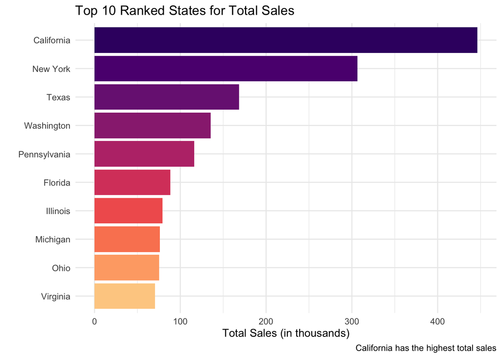

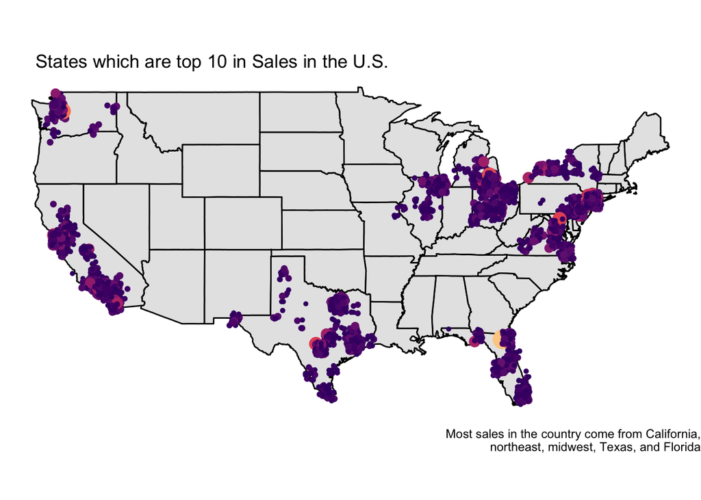

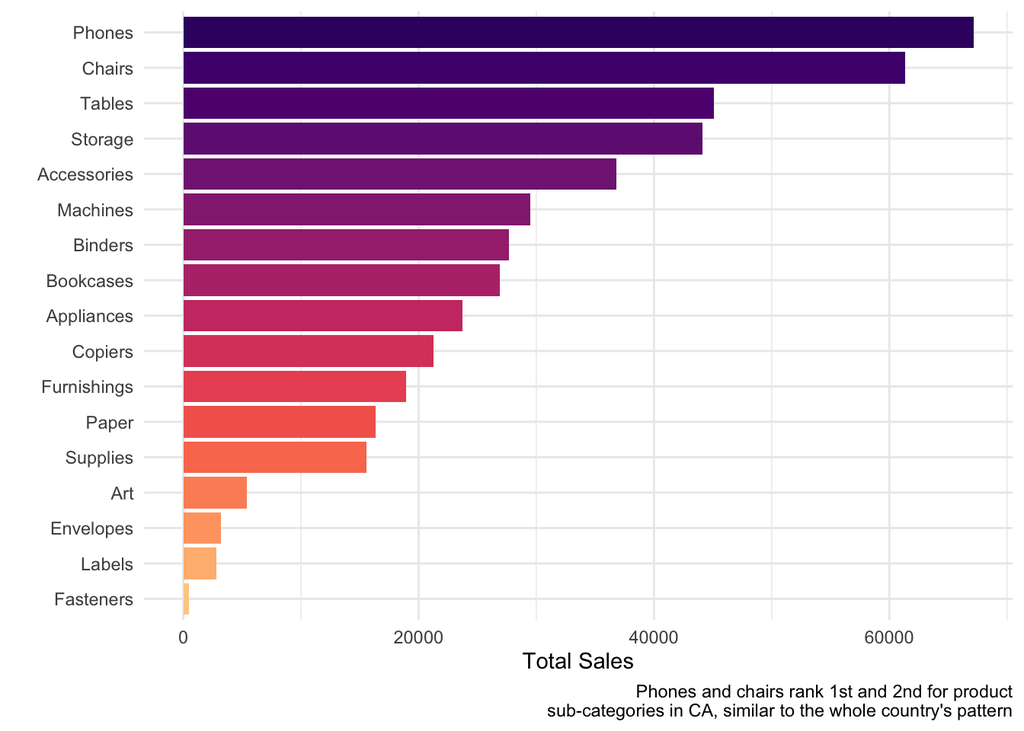

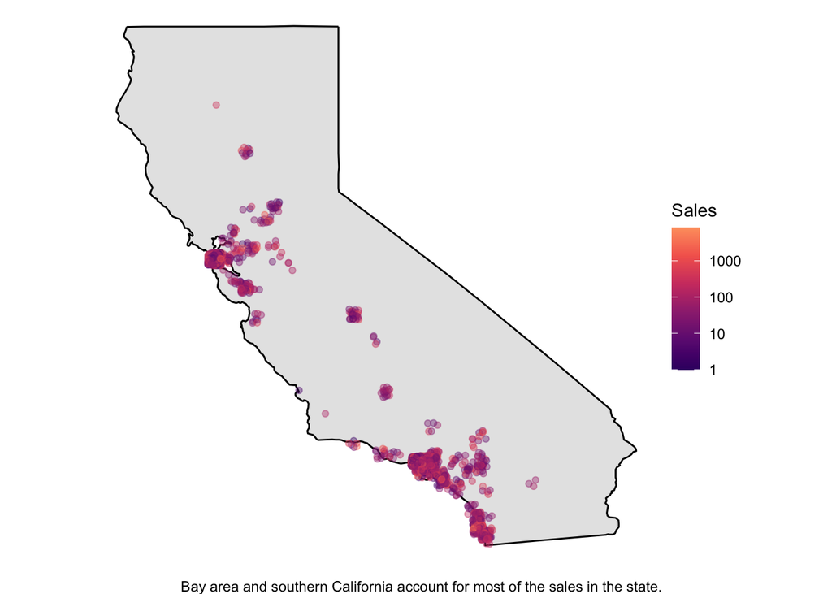

### Visualization 7

*Research Question 3:* How does the market in California look and has it changed?

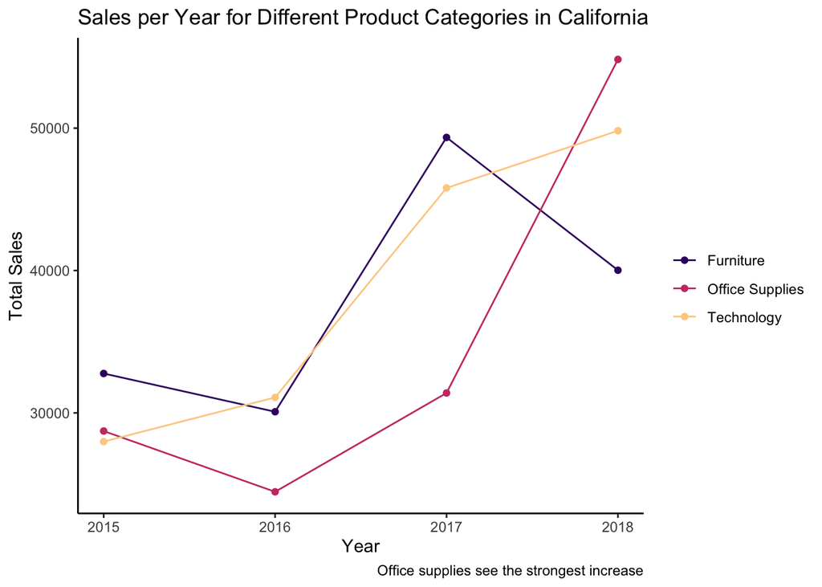

### Visualization 8

*Research Question 4:* How are sales distributed between different sub-categories in California?

The 8th visualization aims to answer my fourth research question. The visual examines the different sale patterns within categories. Interestingly, office supplies has a lot of sales, but they are mostly low numbers. Furniture and technology have similar patterns, with technology having slightly higher sales but slightly less dense distribution.

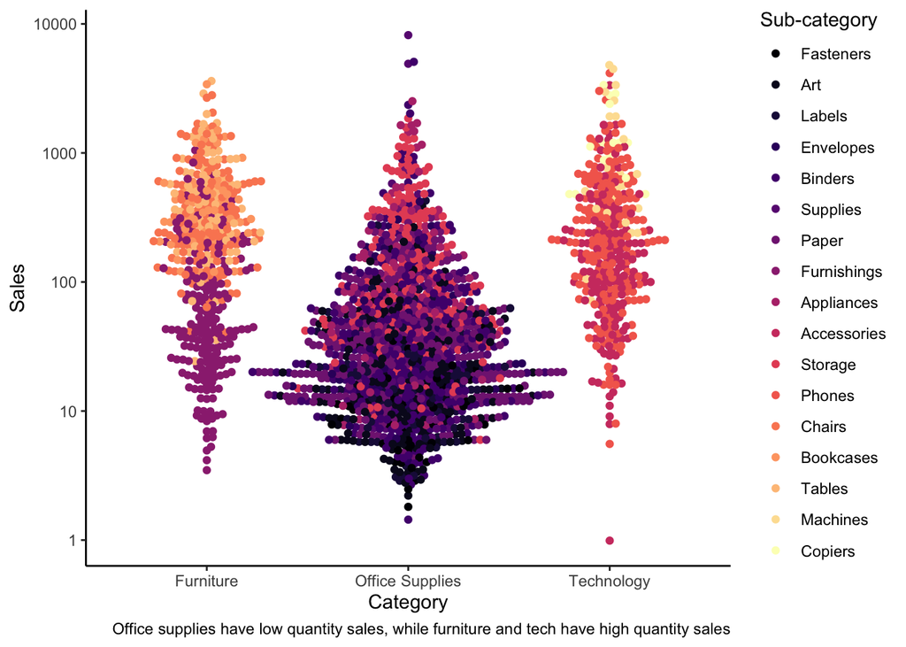

### Recommendation

After careful examination of the data, I would recommend to any large superstore to sell either technology or furniture. These two product categories are more lucrative than office-supplies, and the demand has increases since the start year. I recommend opening stores in California, particularly near the bay area or southern California. Products like phones and chairs are best selling, so if you’re looking to make profits I’d recommend on focusing on one or the other.